# HW1-Fangzhou Song

Fangzhou Song

```r
rm(list=ls())
library(tidyverse)
library(GGally)
```

## Question 1

> Install the titanic package from CRAN and load the titanic_train dataset, and check its help file to learn what the dataset contains.

```r
library(titanic)
data("titanic_train")
glimpse(titanic_train)
```

```
## Observations: 891
## Variables: 12
## $ PassengerId <int> 1, 2, 3, 4, 5, 6, 7, 8, 9, 10, 11, 12, 13, 14, 15,...
## $ Survived    <int> 0, 1, 1, 1, 0, 0, 0, 0, 1, 1, 1, 1, 0, 0, 0, 1, 0,...
## $ Pclass      <int> 3, 1, 3, 1, 3, 3, 1, 3, 3, 2, 3, 1, 3, 3, 3, 2, 3,...
## $ Name        <chr> "Braund, Mr. Owen Harris", "Cumings, Mrs. John Bra...
## $ Sex         <chr> "male", "female", "female", "female", "male", "mal...
## $ Age         <dbl> 22, 38, 26, 35, 35, NA, 54, 2, 27, 14, 4, 58, 20, ...
## $ SibSp       <int> 1, 1, 0, 1, 0, 0, 0, 3, 0, 1, 1, 0, 0, 1, 0, 0, 4,...
## $ Parch       <int> 0, 0, 0, 0, 0, 0, 0, 1, 2, 0, 1, 0, 0, 5, 0, 0, 1,...
## $ Ticket      <chr> "A/5 21171", "PC 17599", "STON/O2. 3101282", "1138...
## $ Fare        <dbl> 7.2500, 71.2833, 7.9250, 53.1000, 8.0500, 8.4583, ...
## $ Cabin       <chr> "", "C85", "", "C123", "", "", "E46", "", "", "", ...
## $ Embarked    <chr> "S", "C", "S", "S", "S", "Q", "S", "S", "S", "C", ...
```

> Remove the PassengerId, Name, Ticket and Cabin columns, and transform the Fare variable by taking its log.

```r
data1= titanic_train %>%
  filter(Embarked!="",Fare!=0,is.na(Age)==FALSE) %>%
  select(Survived,Pclass,Sex:Parch,Fare,Embarked) %>%
  mutate(
    Fare=log(Fare),
    Survived=as.factor(Survived),
    Pclass=as.factor(Pclass),
    Sex=as.factor(Sex)
  )
head(data1,10)
```

```
##    Survived Pclass    Sex Age SibSp Parch     Fare Embarked
## 1         0      3   male  22     1     0 1.981001        S
## 2         1      1 female  38     1     0 4.266662        C
## 3         1      3 female  26     0     0 2.070022        S
## 4         1      1 female  35     1     0 3.972177        S
## 5         0      3   male  35     0     0 2.085672        S
## 6         0      1   male  54     0     0 3.948596        S
## 7         0      3   male   2     3     1 3.048088        S
## 8         1      3 female  27     0     2 2.409941        S
## 9         1      2 female  14     1     0 3.403555        C
## 10        1      3 female   4     1     1 2.815409        S
```

> Choose three variable pairs (for instance, “Sex” and “Survived” is one pair) and plot their distribution in the dataset by using appropriate plots. You can try mosaic plots, densities, histograms. You are asked to provide at least one plot for each pair.

Sex v.s. Survived

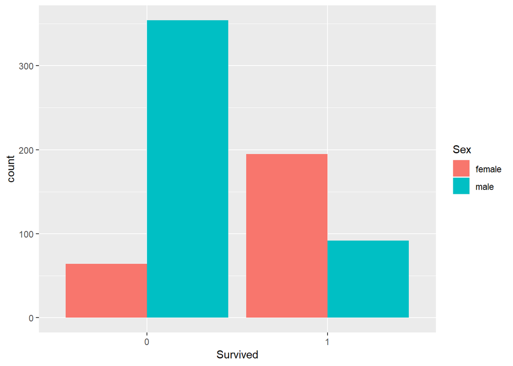

```r
data1 %>%
  ggplot() +
  geom_bar(mapping = aes(x=Survived,fill=Sex),position = "dodge")
```

Pclass v.s. Age

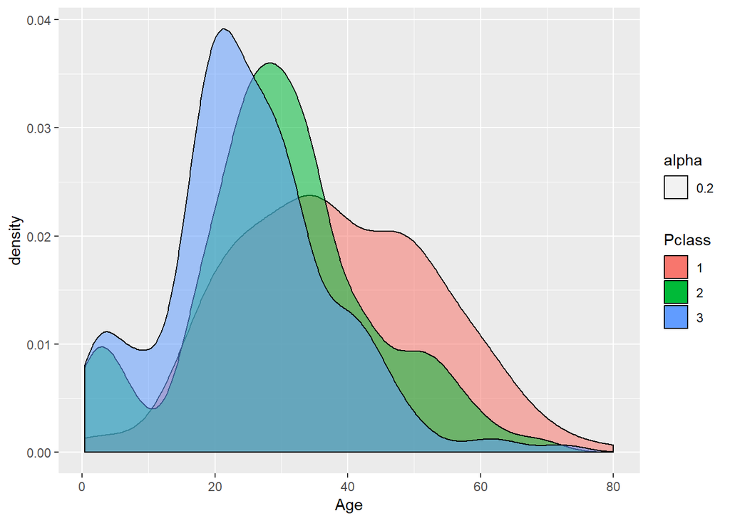

```r
data1 %>%
  ggplot()+
  geom_density(mapping = aes(x=Age,fill=Pclass,alpha=0.2))
```

Age v.s. Fare

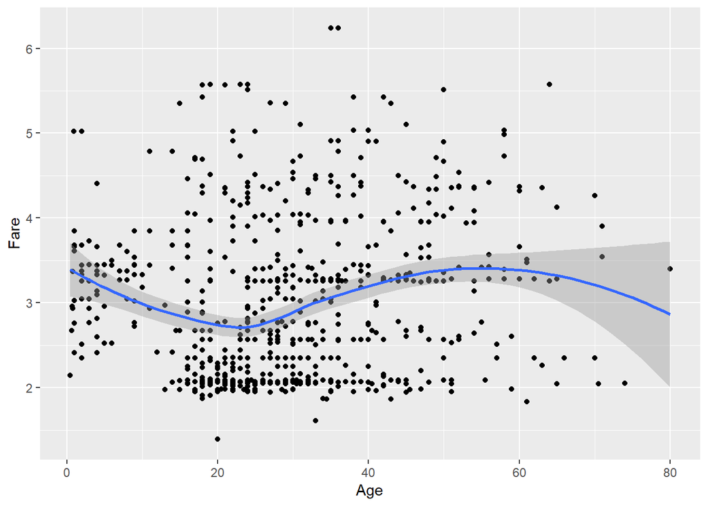

```r
data1 %>%
  ggplot(mapping = aes(x=Age,y=Fare))+
  geom_point()+
  geom_smooth()
```

> Create a model matrix of the dataset that only contains numbers (no factors!) by using the model.matrix function. Then, remove the Survived variable from this dataset.

Matrix that only contains numbers

```r
data1_a=model.matrix(~Survived+Pclass+Age+SibSp+Parch+Fare+Embarked,data1)
data1_a=data1_a[,-1]
head(data1_a,5)
```

```
##   Survived1 Pclass2 Pclass3 Age SibSp Parch     Fare EmbarkedQ EmbarkedS
## 1         0       0       1  22     1     0 1.981001         0         1
## 2         1       0       0  38     1     0 4.266662         0         0
## 3         1       0       1  26     0     0 2.070022         0         1
## 4         1       0       0  35     1     0 3.972177         0         1
## 5         0       0       1  35     0     0 2.085672         0         1
```

Remove the Survived variable from this dataset

```r
data1_b=data1_a[,-1]
head(data1_b,5)
```

```
##   Pclass2 Pclass3 Age SibSp Parch     Fare EmbarkedQ EmbarkedS
## 1       0       1  22     1     0 1.981001         0         1
## 2       0       0  38     1     0 4.266662         0         0
## 3       0       1  26     0     0 2.070022         0         1
## 4       0       0  35     1     0 3.972177         0         1
## 5       0       1  35     0     0 2.085672         0         1
```

> Fit a PCA to your matrix from the previous step. Plot the scores of the observations (use only the first 2 dimensions) and color them according to the Survived variable.

```r
pca=prcomp(data1_b,center = TRUE,scale. = TRUE)
pca$rotation
```

```
##                   PC1        PC2         PC3         PC4         PC5
## Pclass2    0.36714425 -0.2393812 -0.28344550  0.66825184 -0.11222375
## Pclass3   -0.67037012  0.1416326 -0.04110184 -0.13741885 -0.10814542
## Age        0.25507885 -0.3685565  0.27098802 -0.43446975 -0.60282680
## SibSp      0.05726306  0.5861042 -0.17492109  0.09317291 -0.04938814
## Parch      0.13194660  0.5353955 -0.17551390 -0.04906136 -0.48701851
## Fare       0.54556639  0.3347634  0.14999258 -0.28109825  0.16086501
## EmbarkedQ -0.16515616  0.1320152  0.54523246  0.49037236 -0.45321671
## EmbarkedS -0.07166301 -0.1647483 -0.68070262 -0.12337779 -0.37603338
##                   PC6         PC7           PC8
## Pclass2    0.06940775  0.28178992  0.4291651398
## Pclass3    0.03890987  0.19340600  0.6777577183
## Age       -0.19886195  0.35916690  0.0703943506
## SibSp     -0.67181835  0.37692696 -0.1344293745
## Parch      0.63076006  0.08823134 -0.1410657186
## Fare      -0.07596361 -0.37895124  0.5599327673
## EmbarkedQ -0.17801302 -0.42480285  0.0006722524
## EmbarkedS -0.25974074 -0.52940296  0.0032317068
```

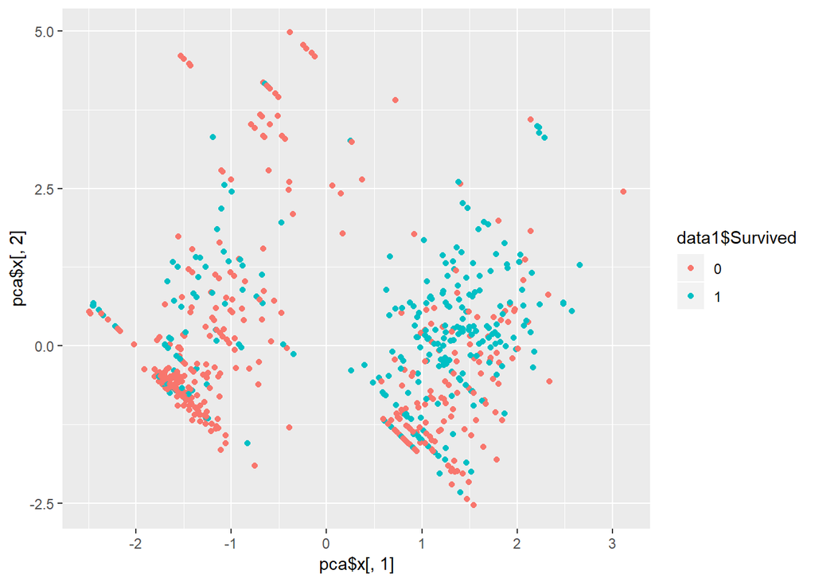

```r
ggplot(data=data.frame(pca$x))+
  geom_point(mapping = aes(x=pca$x[,1],y=pca$x[,2],color=data1$Survived))
```

> Repeat the previous question with NMF (non-negative matrix factorization). Use rank=2 for the fit. Note which variables were chosen.

```r
library(pkgmaker)
library(registry)
library(rngtools)
library(cluster)
library(NMF)
```

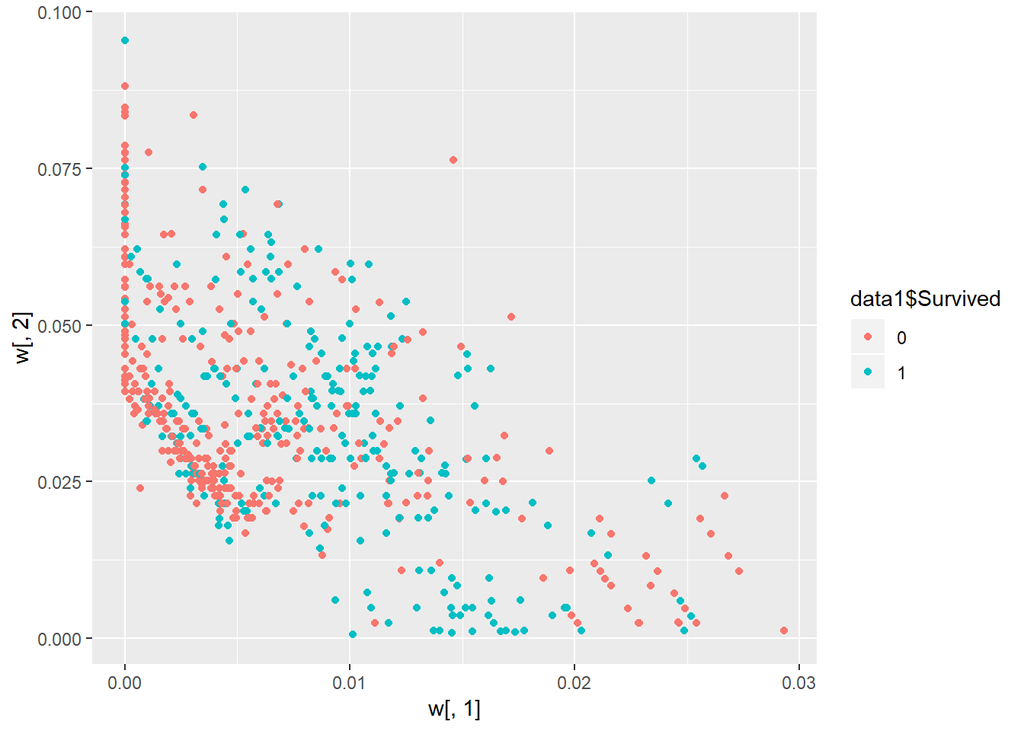

```r
res_nmf=nmf(data1_b,rank = 2,method = "snmf/r")
w=basis(res_nmf)
h=coef(res_nmf)
ggplot(data=data.frame(w))+
  geom_point(mapping = aes(x=w[,1],y=w[,2],color=data1$Survived))
```

> Finally, load the titanic_test dataset. Using your fitted PCA from the previous stages, obtain the 2 dimensional projections of the test dataset. Plot the scores with respect to the Survived variable.

```r
data("titanic_test")
sur=read_csv("titanic3.csv")
sur=rename(sur,Name=name)
```

```r
data1_test= titanic_test %>%
  inner_join(sur,by="Name") %>%
  filter(Embarked!="",Fare!=0,is.na(Age)==FALSE) %>%
  select(survived,Pclass,Sex:Parch,Fare,Embarked) %>%
  mutate(
    survived=as.factor(survived),
    Fare=log(Fare),
    Pclass=as.factor(Pclass),
    Sex=as.factor(Sex)
  )
data1_test_m=model.matrix(~Pclass+Age+SibSp+Parch+Fare+Embarked,data1_test)
data1_test_m=data1_test_m[,-1]
head(data1_test_m,5)
```

```
##   Pclass2 Pclass3  Age SibSp Parch     Fare EmbarkedQ EmbarkedS
## 1       0       1 34.5     0     0 2.057860         1         0
## 2       0       1 34.5     0     0 2.057860         1         0
## 3       0       1 47.0     1     0 1.945910         0         1
## 4       1       0 62.0     0     0 2.270836         1         0
## 5       0       1 27.0     0     0 2.159003         0         1
```

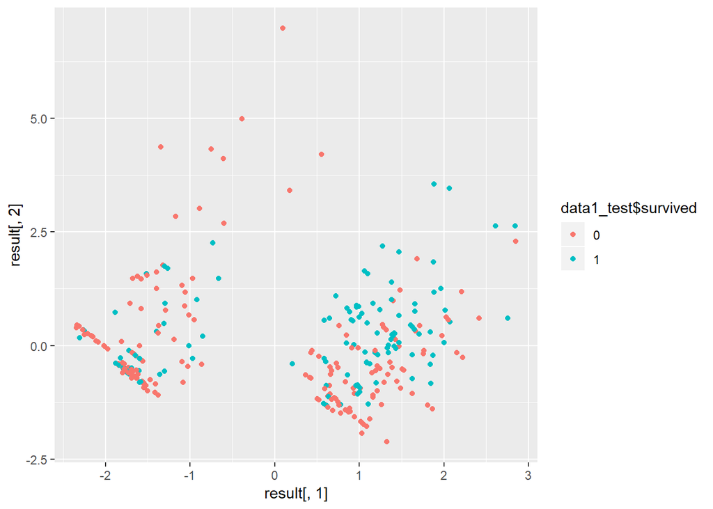

```r
result=scale(data1_test_m) %*% pca$rotation[,1:2]
ggplot(data=data.frame(result))+
  geom_point(mapping = aes(x=result[,1],y=result[,2],color=data1_test$survived))
```

## Question 2

> Choose a dataset from Kaggle, any of the R packages or generate your own dataset by capturing photos from Amazon.com with the “Image Downloader” extension of Google Chrome as we did in class. If the dataset size is too large, randomly choose 2000 samples. Feel free to discard any variables that are not numbers or factors.

```r
library(jpeg)
library(EBImage)
```

Load cat pictures, use gray images, change their size into 400x300 and matrix form

```r
cat_name=paste0("cats/",list.files("cats/"))

convert_image=function(x){
  a=readImage(x)
  a=channel(a,"gray")
  c=resize(a,w=400,h=300)
  return(c)
}

cat_pic_mat=sapply(cat_name,function(x) matrix(convert_image(x),nrow=1))
```

Display several examples of pictures

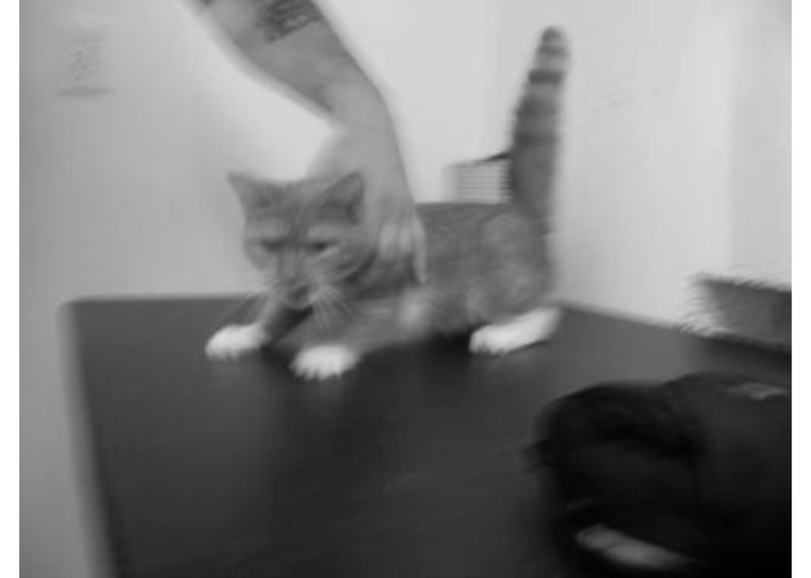

```r
cat_pic_array=array(sapply(cat_name[1:3],convert_image),dim = c(400,300,3))

display(cat_pic_array[,,1])
```

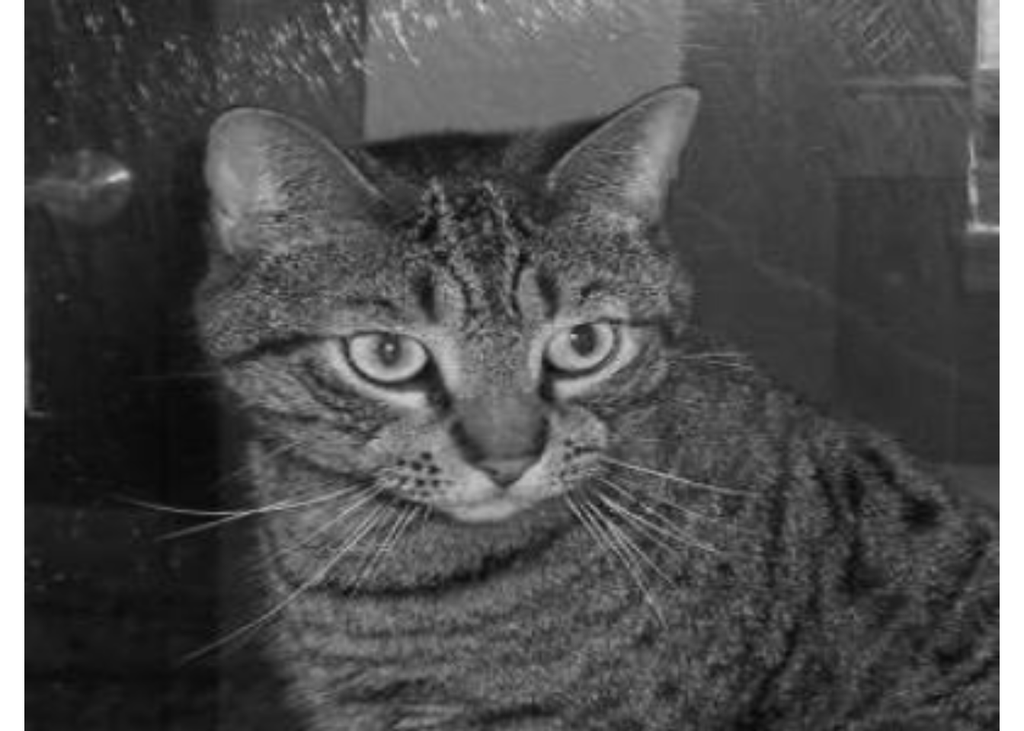

```r
display(cat_pic_array[,,2])
```

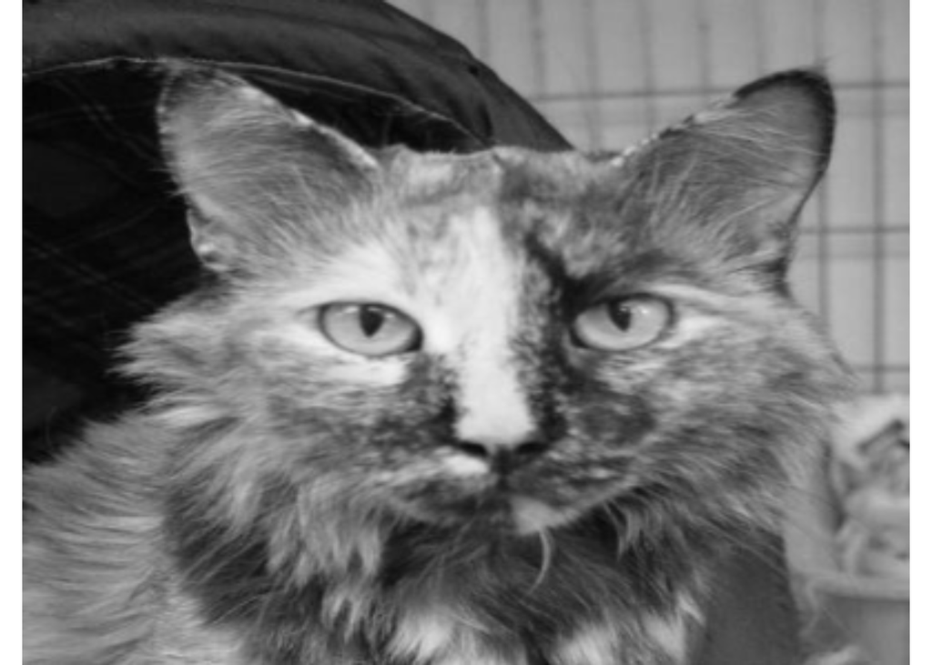

```r
display(cat_pic_array[,,3])
```